# RayCast2D

# Raycasts use rays to detect bodies

`RayCast2D` draws a line from one point to another and tells you the first body it encounters. It can also tell you where the ray and body collide and even the angle of the surface hit.

A `RayCast2D` is helpful for many parts of game development, like firing bullets, finding nearby surfaces, and checking if a path is clear for enemy AI to move.

In this guide, you will learn to:

- Set up a `RayCast2D` and use its key methods.
- Use a `RayCast2D` to find out if a turret can see the player.
- Create weapons like lasers and hit-scan guns.
- Use a `RayCast2D` to detect the floor and where its edges are.
- Detect walls and how far away they are for an AI.

Contents:

- RayCast2D’s key features
  - Setting up your ray with cast_to
  - Getting data with force_raycast_update
  - Checking for collisions with is_colliding and get_collider
  - Getting collision information
  - How normals work
- How to use a RayCast2D in practice
  - Detecting the player with a turret
  - Firing a laser beam
  - Firing a hit-scan spray of bullets
  - Detecting the floor
  - Detecting the edge of a platform
  - Detecting walls for an AI
- Your questions
  - How can I make my RayCast ignore specific bodies?
  - How can I find the shape I’ve detected with a ray?

## RayCast2D’s key features

### Setting up your ray with cast_to

The core of a `RayCast2D` is a `Vector2` property called `cast_to`.

The ray starts from the `RayCast2D`’s position and ends at the offset represented by `cast_to`: the property works in local coordinates.

We get access to all of Godot’s powerful vector tools when creating the line we want to cast. For example, you can use built-in constants to cast in specific directions:

```
var raycast: RayCast2D = get_node("RayCast2D")
var length := 256.0
# Cast a ray towards the left.
raycast.cast_to = Vector2.LEFT * length
```

You can also create a `Vector2` facing an angle using the `rotated()` method.

```
# Cast to 60 degrees right of up (2 o'clock on a clock face)
raycast.cast_to = Vector2.UP.rotated(deg2rad(60)) * length
```

If you know the position of your target, you can cast directly to that point by converting its position to a local coordinate.

```
raycast.cast_to = global_position.to_local(_target.global_position)
```

### Getting data with force_raycast_update

As a physics object, a `RayCast2D` will update its collision information once every frame.

But, if we change `cast_to` with code, the ray won’t use the new value until the next frame.

To update this information as soon as `cast_to` changes, you can call the built-in `force_raycast_update()` function.

Calling this function can be necessary for scripts that alter the `cast_to` property.

### Checking for collisions with is_colliding and get_collider

A good sanity check when finding the result of a `RayCast2D` is to call the `is_colliding()` method. If there’s a collision, it will return `true`. If not, it will return `false`.

If you want to know what `RayCast2D` is colliding with, you need the `get_collider()` method instead. It returns the first body the ray encounters.

If the ray gets interrupted as it checks between the origin and its `cast_to` point, the method returns a body.

Otherwise, no collision happened, and the method returns `null`. You can then perform checks on the body to find out more about it, like its name or type.

Here are some examples of this:

```
var raycast: RayCast2D = get_node("RayCast2D")

# Check the type of the collider
raycast.get_collider() is KinematicBody2d
# Check the name of the collider
raycast.get_collider().name == "player"
# Check if the collider has a method you can call
raycast.get_collider().has_method("take_damage")
```

### Getting collision information

When a `RayCast2D` collides with a body, it can tell us two useful pieces of data about the collision:

- The global position of the collision, using `get_collision_point()`.
- The normal (direction) of the surface hit in the collision, using `get_collision_normal()`.

Before we move on, it’s important to know that these functions only work when the `RayCast2D` collides with something.

When the ray doesn’t collide, `get_collision_point()` and `get_collision_normal()` return `Vector2.ZERO`.

You can reliably check the actual collision point and normal by checking if `is_colliding()` is true first. Then use these two methods to get more collision information.

### How normals work

With that out of the way, we can look at how normals work. The normal of a surface is a line perpendicular outwards from the surface (the blue line below).

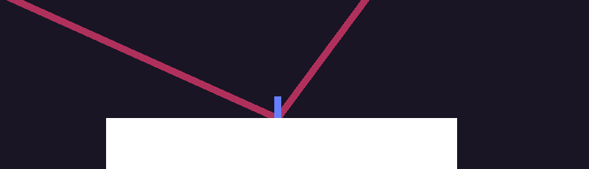

The normal is common in physics when doing calculations with light and forces; we can use it in similar practical ways.

For example, you can use the normal to find what direction to bounce off a surface after a collision or to angle a sprite or particles relative to a surface if you were hitting it with a bullet.

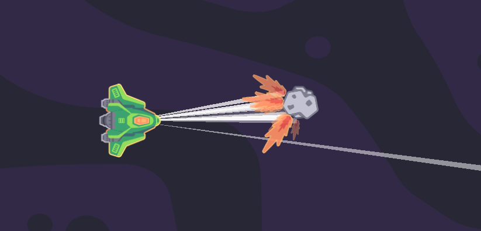

Lastly, you can convert the collision points to local coordinates using the `to_local()` method on any `Node2D`.

## How to use a RayCast2D in practice

### Detecting the player with a turret

There are many cases where finding the first object encountered in a direction is useful. Hitscan bullets and enemy vision checks are common examples.

We will use a `RayCast2D` to find if a turret can see the player or if a wall is in the way.

You can create a turret using a `Sprite` with a `RayCast2D` child. Then, using the *Inspector*, set the `cast_to` of the `RayCast2D` to travel in the direction of your turret.

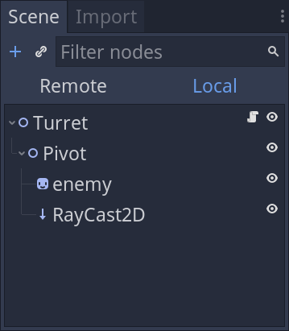

Now you can point the turret towards the player by using the `look_at()` method of the sprite.

```
extends RayCast2D

export var player_path: NodePath
onready var _player: Player = get_node_or_null(player_path)

func _process(delta: float) -> void:
    # Point the turret at the player
    look_at(_player.global_position)
```

While pointing the turret at the player, we can use the `RayCast2D` to detect the first object encountered.

If something is in the way, we know the player is out of sight; we can use this information to show when the player is in danger or not.

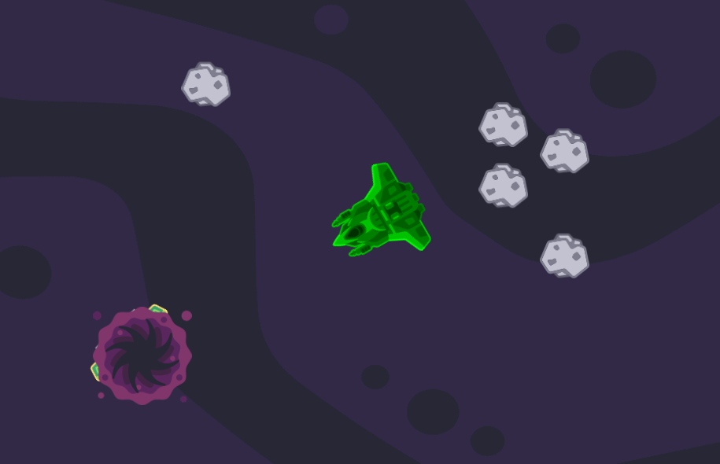

The `RayCast2D` is attached to the turret, so as it rotates, the ray will rotate with it and detect new collisions in every frame.

We can find the first body the ray collides with using the `get_collider()` method. We can then check if this body is the player using our reference to it.

```
func _process(delta: float) -> void:
    #...
    # Set to true if the turret can see the player, false if not.
    var found_player := _raycast.get_collider() == _player
    # If this value has changed, save the new value and play an animation
    if found_player != found_target:
        set_target(found_player)
```

### Firing a laser beam

We can use a `RayCast2D` to fire a laser beam from one point outwards until it collides with a body.

The `get_collision_point()` method will let us know when to stop drawing the laser and position particles showing the beam is colliding with the target.

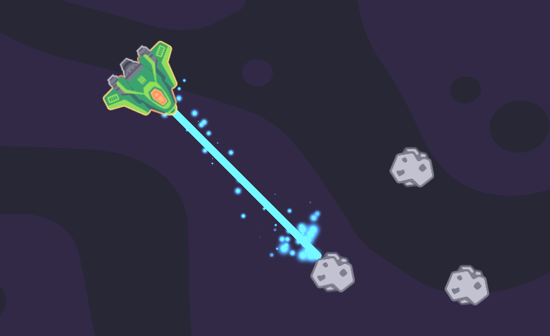

For this effect, we will need:

- The `RayCast2D` itself.
- A `Line2D` to draw the laser.
- `Particles2D` nodes, to indicate that the laser is hitting a surface.

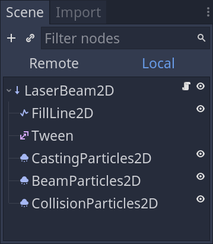

Our laser is cast from one point in `_physics_process()` until the beam is at its maximum length. As the ray’s length changes every frame, we need to `force_raycast_update()` to check collisions accurately.

Because the ray is a child of the player, we can cast it in one direction straight out to the right, and it will rotate with the player.

[figure not shown]

```
export var cast_speed := 7000.0
export var max_length := 1400.0

func _physics_process(delta: float) -> void:
    # Increase the length of the ray every frame until it reaches a max length
    cast_to = (cast_to + Vector2.RIGHT * cast_speed * delta).clamped(max_length)
    # Cast beam is responsible for checking for collisions up to the length we
    # have set
    cast_beam()
```

Most of the legwork will then go in our `cast_beam()` function.

Calling `force_raycast_update()` will update the ray to have accurate collision information; this is necessary because the length of our ray is changing every frame.

First, we should check if we’re colliding with `is_colliding()`. If so, we can call `get_collision_point()` to find where the collision has occurred. Without the `is_colliding()` check first, we would get collision points at `Vector2.ZERO`.

The collision point returned by `get_collision_point()` is a global position. We want to draw a line to this spot using a `Line2D` which uses local coordinates. We can convert these global coordinates using the `to_local()` method.

```
onready var fill := $FillLine2D
onready var collision_particles := $CollisionParticles2D

# Controls the emission of particles and extends the Line2D to `cast_to` or the
# ray's
# collision point, whichever is closest.
func cast_beam() -> void:
    var cast_point := cast_to

    force_raycast_update()
        # Only emit collision particles if there is a collision.
    collision_particles.emitting = is_colliding()

    if is_colliding():
                # Convert the global collision point to a local coordinate
        cast_point = to_local(get_collision_point())
                # Align the collision particles with the surface using its
                # collision normal.
        collision_particles.global_rotation = get_collision_normal().angle()
        collision_particles.position = cast_point
    # Draw our line up until the collision point and stop.
    fill.points[1] = cast_point
```

### Firing a hit-scan spray of bullets

If you want to make any ranged weapon with a high rate of fire, a `RayCast2D` is excellent for fast “hit-scan” weapons.

Raycasting is cheap for the engine to perform; many raycasts can be done quickly without affecting the game’s performance.

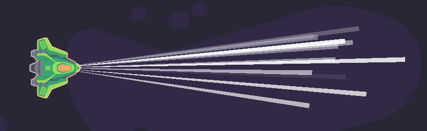

When spraying many bullets, it is helpful to have a random spread. Of course, you can use random number generation, but if you want more natural, smooth transitions from one angle to the next, *OpenSimplexNoise* is ideal.

Noise in Godot is highly customizable. There are three main steps to using it in a script:

1. Export an *OpenSimplexNoise* variable in your script.
2. Create a new *OpenSimplexNoise* in the *Inspector* and customize its properties.
3. Call `get_noise_1d(OS.get_ticks_msec())` to get a number based on the current time.

The *OpenSimplexNoise* resource is very flexible; you can speed it up or slow it down with the period parameter, try a new seed and even save the resource to use elsewhere.

```
export var noise: OpenSimplexNoise
var spray_angle_range := PI / 8.0
```

We can offset the rotation of our ray by this random number to get the direction of our bullet.

With this direction, we can multiply it by a random range to have some bullets fire further than others to add some visual flair.

```
# The following properties define the minimum and maximum length of the ray.
var min_range := 500.0
var max_range := 750.0
# The `cast_to` ray we use when shooting, to both draw the shot and to detect impacts.
var shoot_vector := Vector2.UP.rotated(spray_rotation) * rand_range(min_range, max_range)
```

Finally, we can pass information about the ray and its collisions to a new scene. The new scene will draw a bullet trail. Add this to the same script as before:

```
# We have a scene that animates the bullet spray we can instance and draw
# based on our ray.
export var spray_scene: PackedScene
# This is the ray we use to detect what we shot.
onready var _ray: RayCast2D = $RayCast2D

func shoot() -> void:
    # We use the noise to randomize each shot's rotation and fire in a cone.
    var spray_rotation = spray_angle_range * noise.get_noise_1d(OS.get_ticks_msec())

    var spray = spray_scene.instance()

    add_child(spray)
    # We draw our ray along the vector we just created then update the collision
    # information
    _ray.cast_to = shoot_vector
    _ray.force_raycast_update()
    if _ray.is_colliding():
        # If our bullet collides, we can let our spray scene know where the
        # collision happened and the angle of the surface.
        spray.setup(global_position, _ray.get_collision_point())
        spray.hit(_ray.get_collision_point(), _ray.get_collision_normal())
    else:
        spray.setup(global_position, to_global(shoot_vector))
```

The new spray scene contains:

- A `Line2D` for the bullet’s trail.
- A `Sprite` for showing bullet impacts.
- An `AnimationPlayer` to play the animation, then call `queue_free()` on the spray scene.

The `hit()` function will position a sprite where the collision point is to show the bullet has found a target, and the `setup()` function will draw the line from the origin to the shoot vector.

Then, an animation begins that will fade the trail out and delete the instance.

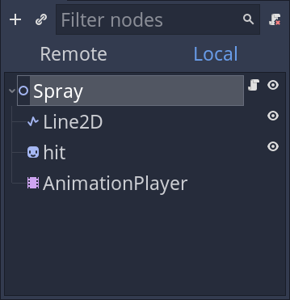

```
onready var _animator: AnimationPlayer = $AnimationPlayer
onready var _line: Line2D = $Line2D
onready var _hit: Sprite = $hit

func setup(origin, target):
    # If the scene isn't ready yet, accessing Line2D's points will cause a
    # crash.
    # We call yield to wait until it's ready.
    if not is_inside_tree():
        yield(self, "ready")
    _line.points[0] = origin
    _line.points[1] = target
    _animator.play("shoot")


func hit(collision_point, collision_normal):
    _hit.visible = true
    _hit.position = collision_point
    # Our sprite is rotated 90 degrees so we subtract that in radians to angle
    # it correctly.
    _hit.rotation = collision_normal.angle() - PI / 2.0
```

### Detecting the floor

Detecting when a body is on the floor is essential for sidescrollers as it can inform many things, such as whether the player can jump or attack.

You can use a `RayCast2D` to detect when a body is on the floor by pointing it in the direction of gravity. Using a ray like this isn’t helpful for `KinematicBody2D` nodes as they have a built-in `is_on_floor()` method. However, when using a `RigidBody2D`, or in situations where gravity often changes direction, a `RayCast2D` is a great way to tackle the problem.

We will have a `RigidBody2D` player character with a `CollisionShape2D`, a `Sprite`, and a `RayCast2D` to detect the floor.

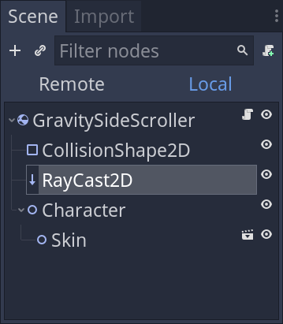

In a `RigidBody2D`, we can find the direction of gravity from the state in the `_integrate_forces()` function as it has a `total_gravity` property. You can cast your ray in that direction a small distance. If it collides, we know there is a surface in that direction the body can stand on.

[figure not shown]

We do this in a custom `is_on_floor()` method. It takes the direction of `total_gravity` as a parameter and returns if the ray has found the floor.

You can then use the `is_on_floor()` method to check if the player can jump whenever they press the jump button.

**Note:** In this example, we only use the `RayCast2D` to detect if our character is standing on the ground.

The gravity switching mechanic is separate and handled by a feature of `Area2D`: you can use an `Area2D` to create specific gravity points.

These will affect the `total_gravity` property of our state. Otherwise, the body will use the project’s `default_gravity` setting.

```
extends RigidBody2D

const GRAVITY_STRENGTH := 5800.0
const JUMP_STRENGTH := 4400.0

onready var _raycast := $RayCast2D


func _integrate_forces(state: Physics2DDirectBodyState) -> void:
    # Get the direction of gravity from our player. Normalize it to get just the
    # direction.
    var local_gravity := state.total_gravity.normalized()
    # ...
    # If the player presses jump, check they are on the floor, if so apply a
    # force in the opposite direction to gravity
    if Input.is_action_just_pressed("jump") and is_on_floor(local_gravity):
        state.apply_central_impulse(-local_gravity * JUMP_STRENGTH)
    # Apply an extra force towards the source of gravity to fall faster.
    state.apply_central_impulse(state.step * local_gravity * GRAVITY_STRENGTH)


func is_on_floor(gravity_in: Vector2):
    # Point the raycast towards gravity and update its collision information
    _raycast.rotation = gravity_in.angle()
    _raycast.force_raycast_update()
    return _raycast.is_colliding()
```

### Detecting the edge of a platform

You may want to detect the edge of a platform for many reasons. For example, you can make it harder to fall off ledges, turn an enemy AI around at a border, or playing a teetering animation on the edge of a cliff. `RayCast2D` is an excellent option for detecting platform edges.

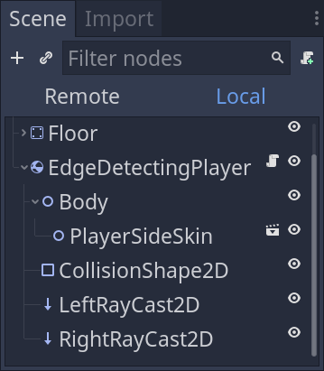

If one of the rays isn’t colliding, then there’s no floor on that side of your player. We can use this information to stop the player from moving.

[figure not shown]

```
onready var _left_ray: RayCast2D = $LeftRayCast2D
onready var _right_ray: RayCast2D = $RightRayCast2D

func _integrate_forces(state: Physics2DDirectBodyState) -> void:
    # Simple movement controls
    # ...
    # If the left side isn't colliding, there is no floor - stop us moving left
    if not _left_ray.is_colliding():
        # Don't let x velocity go below 0.0
        state.linear_velocity.x = max(0.0, state.linear_velocity.x)
    # If the right side isn't colliding, there is no floor - stop us moving
    # right
    if not _right_ray.is_colliding():
        # Don't let x velocity go above 0.0
        state.linear_velocity.x = min(0.0, state.linear_velocity.x)
```

You can learn more about creating controllable characters and movement in the KinematicBody2D and RigidBody2D guides.

### Detecting walls for an AI

A `RayCast2D` is a capable tool for simple logic with AI. `RayCast2D` can be used to detect collisions, calculate distances and check if the player is visible to an AI.

We can use a `RayCast2D` to tell an AI if a wall is in the way and how far away the AI is from that wall. This information can let the AI turn faster if the wall is getting dangerously close.

It’s helpful to be able to find the ratio of how close an object is. A typical example is in shooter games where gun damage is based on distance.

[figure not shown]

We will need a body of some kind for our AI. Here, we use a `RigidBody2D` and two rays: one angled ahead and to the left, and the other ahead and to the right.

We can use these rays to figure out whether to turn left or right: if there’s something to the left, we should turn the other way to avoid it.

We can also test how close the wall is and use that information to turn faster if the wall is closer, as this indicates we are about to crash.

[output not shown]

Now we have our distance ratio; the AI can figure out how much to turn left or right to avoid incoming walls.

[output not shown]

## Your questions

### How can I make my RayCast ignore specific bodies?

There are four approaches you could take to ignore certain collisions:

1. Adding a collision layer explicitly for the ray and target to collide.
2. Using the ray’s `add_exception` method to ignore that node explicitly.
3. Restricting the ray to only collide with areas or bodies specifically.
4. Checking the type of the collider with the `get_collider` function.

All four of these have their own merits. The first three have the benefits of reducing the amount of code you need to write but requiring you to remember these settings when you add new bodies that you may or may not want to collide with the ray.

### How can I find the shape I’ve detected with a ray?

A body can have more than one collision shape. For example, you could have a weak spot on a head that takes extra damage or have a body that changes shape and uses different collision shapes. The `RayCast2D` has a built-in method for accessing the specific shape in a collision: `get_collider_shape()`.

The way Godot handles shapes is efficient, but it’s hard to read, as you need to interact directly with indexes that represent shapes.

When you call `get_collider_shape()`, it returns an integer id for that shape. However, the only node that can tell which shape it was from is the owner of the shape.

If you have a `KinematicBody2D` with a “weak spot” shape and a “body” shape, `get_collider_shape()` returns a different id for each of these.

One will be index `0` and the other index `1`. All collision objects have methods for identifying these shapes.

For example, the `shape_owner_get_owner()` method will return the collision shape associated with a given index.

In our example, `$KinematicBody2D.shape_owner_get_owner(0)` could return the “weak spot” collision shape.

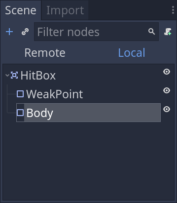

If we combine `get_collider_shape()` and `shape_owner_get_owner()`, we can get the node for the collision shape our raycast is colliding with:

```
func get_collision_shape(_raycast: RayCast2D) -> Node2D:
    return _raycast.get_collider().shape_owner_get_owner(_raycast.get_collider_shape())
```